# Machine Learning For Signal Processing (ENGR-E 511) Homework 3 , Spring 2022

**Name: Anitha Ganapathy**  
**Email: aganapa@iu.edu**

Organizing the imports

```python
# Import the necessary libraries

from PIL import Image
import numpy as np
import pandas as pd
import matplotlib.pyplot as plt
# import matplotlib.mlab as mlab
import librosa
import soundfile as sf
from IPython.display import Audio
import cmath, math
import scipy.io  # to read .mat files
import seaborn as sns
from numpy.core.fromnumeric import size

from google.colab import drive

drive.mount('/content/drive')
```

```python
dirpath = '/content/drive/MyDrive/MLSP_data/'
!ls $dirpath
```

```
'HW_1 data'   IMG_1878.JPG   piano.wav	   x_ica_2.wav	 x_ica_4.wav
'HW_2 data'   ocean.wav      x_ica_1.wav   x_ica_3.wav
```

## **P1: DCT and PCA**

```python
img = Image.open(dirpath+'IMG_1878.JPG')
luddy = np.asarray(img)

print(luddy.shape)
```

```
(1024, 768, 3)
```

Divide the 3D array (1024 × 768 × 3) into the three channels. Let’s call them X_R, X_G, and X_B.

```python
X_R = luddy[:,:,0]
X_G = luddy[:,:,1]
X_B = luddy[:,:,2]
```

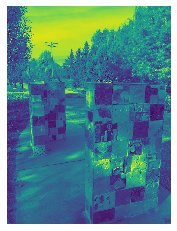

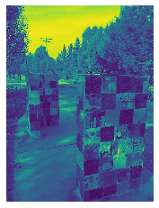

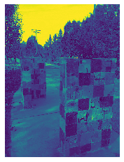

```python
plt.imshow(X_R, interpolation='nearest')
plt.axis(False)
plt.show()

plt.imshow(X_G, interpolation='nearest')
plt.axis(False)
plt.show()

plt.imshow(X_B, interpolation='nearest')
plt.axis(False)
plt.show()
```

Randomly choose a block of 8 consecutive (entire) rows from XR, e.g. XR (113:120,1:768)

```python
X_R.shape
```

```
(1024, 768)
```

```python
idx = np.random.randint(low=0, high=1010)
R = X_R[idx: idx+8, :]
R.shape
```

```
(8, 768)
```

```python
plt.imshow(R)
```

[output not shown]

```python
def luddy_block_generation(block_zize):
  idx = np.random.randint(low=0, high=1010)
  R = X_R[idx: idx+8, :]

  img_data = [X_R, X_G, X_B]
  n_times = [block_zize - 1 ,block_zize, block_zize]
  for n, data in zip(n_times, img_data):
    for i in range(n):
      idx = np.random.randint(low=0, high=1010)
      img_block = X_R[idx: idx+8, :]
      R = np.hstack((R, img_block))
  R = R.astype('float64')
  print("R shape : ", R.shape)
  return R
```

```python
def plot_eigen_matrix(R, n):
  R_mean = np.mean(R, axis=1).reshape((-1, 1))
  print("R mean shape :", R_mean.shape)
  # print(R_mean)

  # Subtract the mean vector of size 8 × 1 from all 6912 vectors.
  R -= R_mean

  # Calculate the covariance matrix, which will be an 8 × 8 matrix
  covMatrix = np.cov(R,bias=True)
  # print("The covariance matrix is :\n",covMatrix)
  plt.figure(figsize=(6,6))
  plt.imshow(covMatrix)

  # Do eigendecomposition on the covariance matrix and extract 8 eigenvectors(V), each of which is with 8 dimensions.
  V, W = np.linalg.eigh(covMatrix)
  print("Eigen Vector shape:", V.shape)
  print("Eigen Matrix shape:", W.shape)
  print("Eigen Vector : \n", V)
  # Plot your W.⊤
  # sns.heatmap(np.round(W.T, 1), annot=False)
  plt.imshow(W.T, cmap='Blues', interpolation='nearest')
  plt.title(f'Eigen Matrix for block size ' +str(n), size=20)
  plt.colorbar()
  plt.axis(False)
  plt.show()
```

### Plotting Eigen Matrix for block size = 3

```
R shape :  (8, 6912)
R mean shape : (8, 1)
Eigen Vector shape: (8,)
Eigen Matrix shape: (8, 8)
Eigen Vector :
 [   49.92041762   106.59453996   175.64256118   216.93585307
   345.68468107   741.50225745  1106.24870229 21879.45627118]
```

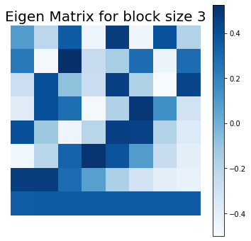

```python
R_3 = luddy_block_generation(3)
plot_eigen_matrix(R_3, 3)
```

### ## Plotting Eigen Matrix for block size = 30

```
R shape :  (8, 69120)
R mean shape : (8, 1)
Eigen Vector shape: (8,)
Eigen Matrix shape: (8, 8)
Eigen Vector :
 [   57.85735944   110.17624481   181.27445372   272.78413176
   362.67045323   580.37423617  1064.49373804 26287.6022275 ]
```

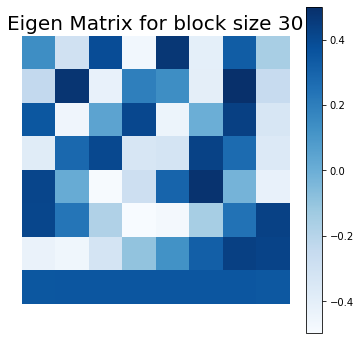

```python
R_30 = luddy_block_generation(30)
plot_eigen_matrix(R_30, 30)
```

### For easy comparison of plot without any print statements

```python
# For easy comparison of plot without any print statements

def plot_eigen_decomposition(R, n):
  R_mean = np.mean(R, axis=1).reshape((-1, 1))

  # Subtract the mean vector of size 8 × 1 from all 6912 vectors.
  R -= R_mean

  # Calculate the covariance matrix, which will be an 8 × 8 matrix
  covMatrix = np.cov(R,bias=True)
  V, W = np.linalg.eigh(covMatrix)

  # Do eigendecomposition on the covariance matrix and extract 8 eigenvectors(V), each of which is with 8 dimensions.
  plt.imshow(W.T, cmap='Blues', interpolation='nearest')
  plt.title(f'Eigen Matrix for block size ' +str(n), size=20)
  plt.colorbar()
  plt.axis(False)
  plt.show()
```

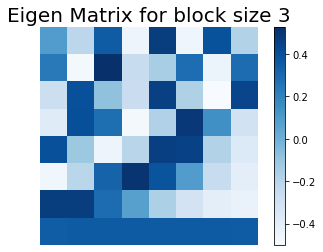

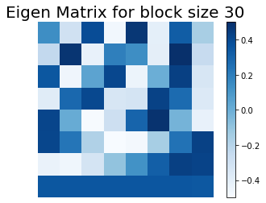

```python
plot_eigen_decomposition(R_3, 3)
plot_eigen_decomposition(R_30, 30)
```

**Conclusion**

- From the above plots for block size 3 nd 30 , te row vector size was 6912 and 69120 respectively.
- We can conclude that when we increase the number of samples that we input to our covariance matrix our covariance weights gets much better.
- Comparing both the plots, the plot using 90 samples has captured higher variance than the plot using 9 samples.

## **P2: Instantaneous Source Separation**

```python
!ls $dirpath
```

```
'HW_1 data'   IMG_1878.JPG   piano.wav	   x_ica_2.wav	 x_ica_4.wav
'HW_2 data'   ocean.wav      x_ica_1.wav   x_ica_3.wav
```

### Load the sound 4 files

```python
# Load the x.wav file using librosa

file1= dirpath + 'x_ica_1.wav'
file2= dirpath + 'x_ica_2.wav'
file3= dirpath + 'x_ica_3.wav'
file4= dirpath + 'x_ica_4.wav'

x1, sr1 = librosa.load(file1 , sr = None)
x2, sr2 = librosa.load(file2 , sr = None)
x3, sr3 = librosa.load(file3 , sr = None)
x4, sr4 = librosa.load(file4 , sr = None)
```

```python
x1.shape, x2.shape, x3.shape, x4.shape, sr1, sr2, sr3, sr4
```

```
((42292,), (42292,), (42292,), (42292,), 16000, 16000, 16000, 16000)
```

### Original Audio signals

```python
Audio(x1, rate = sr1)
```

[interactive chart not shown]

```python
Audio(x2, rate = sr2)
```

[interactive chart not shown]

```python
Audio(x3, rate = sr3)
```

[interactive chart not shown]

```python
Audio(x4, rate = sr4)
```

[interactive chart not shown]

```python
X = np.vstack((x1,x2,x3,x4))
```

```python
X.shape
```

```
(4, 42292)
```

### Building the covariance matrix and the Eigen vectors and Eigen Matrix

https://learndataa.com/2020/09/15/data-preprocessing-whitening-or-sphering-in-python/

- Zero-center data: $$ x_{\text {centered }}=x-x_{\text {mean }} $$

where,

x_centered: centered data for a feature  
x: is individual data point for a feature  
xmean: mean value for a feature

- Covariance matrix: $$ \begin{gathered} x_{\text {variance }}=\frac{\sum_{i=1}^{n}\left(x_{i}-x_{\text {mean }}\right)^{2}}{n} \\ \\ \text { covariance }=\frac{\sum_{i=1}^{n}\left(x_{i}-x_{\text {mean }}\right)\left(y_{i}-y_{\text {mean }}\right)}{n} \end{gathered} $$

$$ x_{\text {variance }}=\frac{\sum_{i=1}^{n}\left(x_{i}-x_{\text {mean }}\right)^{2}}{n-1} $$$$ x_{\text {covariance }}=\frac{\sum_{i=1}^{n}\left(x_{i}-x_{\text {mean }}\right)\left(y_{i}-y_{\text {mean }}\right)}{n-1} $$

where:

x_variance: is variance for a feature  
x_covariance: is covariance between features x and y  
xi and yi: is individual data point for feature x and y  
x_mean and y_mean: mean value for features x and y  
∑: indicates sum of values  
n: is the number of observations for a feature

- Eigenvalues and Eigenvectors: $$ A-\lambda I=0 $$ Equation 6: Substitute covariance matrix for 'A' and solve the simultaneous equations to calculate ' $\lambda$ ' i.e. Eigenvalues $$ A v=\lambda v $$ Equation 7 : Substitute the Eigenvalues ' $\lambda$ ' from above Equation# 6 along with the covariance matrix 'A' to calculate the Eigenvectors.
  where:

A: Covariance matrix of features  
λ: is the matrix for Eigenvalues  
I: is identity matrix  
v: is the matrix for Eigenvectors

- Whitening using PCA: $$ W_{P C A}=\Lambda^{\frac{-1}{2}} U^{T} X $$

where:

X: Feature data  
Λ: is the matrix for Eigenvalues (above is inverse square root)  
UT: is transpose of matrix for Eigenvectors

- Whitening using ZCA:

$$ W_{Z C A}=U \Lambda^{\frac{-1}{2}} U^{T} X $$

Equation 9: Whitening transformation using ZCA.

X: Feature data  
Λ: is the matrix for Eigenvalues (above is inverse square root)  
UT: is transpose of matrix for Eigenvectors

https://stackoverflow.com/questions/6574782/how-to-whiten-matrix-in-pca

```python
def pca_whitening(X_in):
  # zero centered data set.
  X_in = X_in - np.mean(X_in, axis =1).reshape(-1,1)

  # Calculate the covariance matrix, which will be an 4 × 4 matrix
  covMatrix = np.cov(X_in,bias=True)
  print("The covariance matrix is :\n",covMatrix)

  # Do eigendecomposition on the covariance matrix and extract 8 eigenvectors(V), each of which is with 8 dimensions.
  d, V = np.linalg.eigh(covMatrix)
  print("\nEigen Vector shape:", d.shape)
  print("\nEigen Matrix shape:", V.shape)
  print("\nEigen Vector : \n", d)
  print("\nEigen Matrix : \n", V)

  epsilon = 1e-5
  # a fudge factor can be used so that eigenvectors associated with
  # small eigenvalues do not get overamplified.
  D = np.diag(1. / np.sqrt(d+epsilon))

  # whitening matrix
  W = np.dot(np.dot(V, D), V.T)

  # multiply by the whitening matrix
  X_white = np.dot(W, X)

  return X_white, W
```

```python
X_white, W = pca_whitening(X)
```

```
The covariance matrix is :
 [[0.01801978 0.01548943 0.02057732 0.00537587]
 [0.01548943 0.01332697 0.01768662 0.00466546]
 [0.02057732 0.01768662 0.02349937 0.00612729]
 [0.00537587 0.00466546 0.00612729 0.00180565]]

Eigen Vector shape: (4,)

Eigen Matrix shape: (4, 4)

Eigen Vector :
 [1.10565686e-07 1.65865482e-06 2.00802485e-04 5.64492013e-02]

Eigen Matrix :
 [[ 0.57402505  0.57704042  0.13555186 -0.56492946]
 [ 0.34637361 -0.7956744  -0.1043899  -0.48582951]
 [-0.73244418  0.04714704  0.21253735 -0.64508182]
 [-0.11851619  0.1780555  -0.96205837 -0.16939255]]
```

```python
print(X_white.shape, W.shape)
print(X_white)
```

```
(4, 42292) (4, 4)
[[ 0.32219413  0.49540998  0.38311594 ... -0.87572582 -0.95231391
  -0.97278461]
 [ 0.26729557  0.41315743  0.31019791 ... -0.73332107 -0.79604056
  -0.82094042]
 [ 0.38265047  0.57888408  0.43585391 ... -1.02844515 -1.11402443
  -1.15362798]
 [ 0.01149907  0.02884816  0.02768116 ... -0.05323709 -0.06682514
  -0.05941852]]
```

### **Independent Component Analysis**

At every iteration of the ICA algorithm, use these as your update rules:
$$ \begin{aligned} \Delta \boldsymbol{W} & \leftarrow\left(N \boldsymbol{I}-g(\boldsymbol{Y}) f(\boldsymbol{Y})^{\prime}\right) \boldsymbol{W} \\ \boldsymbol{W} & \leftarrow \boldsymbol{W}+\rho \Delta \boldsymbol{W} \\ \boldsymbol{Y} & \leftarrow \boldsymbol{W} \boldsymbol{Z} \end{aligned} $$

```python
def Independent_Component_Analysis(Z, lr, N):
    delta_W= np.identity(4)
    W = np.identity(4)
    Y = np.dot(W,Z)
    I = np.identity(4)

    for i in range(0, 1000):
        delta_W = np.dot((N * I - np.dot(np.tanh(Y), np.power(Y, 3).T)), W)
        W = W + lr *delta_W
        Y = np.dot(W,Z)
    return Y, W
```

```python
%%time
Y, W = Independent_Component_Analysis(X_white, 0.000001, X_white.shape[1])
```

```
CPU times: user 33.8 s, sys: 25.1 s, total: 58.9 s
Wall time: 34.7 s
```

```python
src = np.dot(W, X_white)
print(src.shape)
```

```
(4, 42292)
```

### Recovered sources

```python
Audio(Y[0,:], rate = sr1)
```

[interactive chart not shown]

```python
Audio(Y[1,:], rate = sr1)
```

[interactive chart not shown]

```python
Audio(Y[2,:], rate = sr1)
```

[interactive chart not shown]

```python
Audio(Y[3,:], rate = sr1)
```

[interactive chart not shown]

### **Transcripts**

1. Bike sound
2. Its not easy to create illuminating examples
3. Twenty two or twenty three
4. I ate every oyester on Nora's plate

## **P3: Ideal Masks**

```python
!ls $dirpath
```

```
'HW_1 data'   IMG_1878.JPG   piano.wav	   x_ica_2.wav	 x_ica_4.wav
'HW_2 data'   ocean.wav      x_ica_1.wav   x_ica_3.wav
```

```python
p_file = dirpath + 'piano.wav'
c_file = dirpath + 'ocean.wav'
piano, sr1 = librosa.load(p_file , sr = None)
ocean, sr1 = librosa.load(c_file , sr = None)
```

### Original S and N i.e piano and ocean signals

```python
Audio(piano, rate = sr1)
```

[interactive chart not shown]

```python
Audio(ocean, rate = sr1)
```

[interactive chart not shown]

```python
S = librosa.stft(piano,  n_fft=1024, hop_length  = 513,  window='hann')
N = librosa.stft(ocean,  n_fft=1024, hop_length  = 513,  window='hann')
```

```python
S.shape , N.shape
```

```
((513, 156), (513, 156))
```

```python
# S = np.real(S)
# N = np.real(N)
```

```python
S.shape , N.shape
```

```
((513, 156), (513, 156))
```

```python
X = S + N
```

### Ideal Masks

M = S / (S + N)

```python
M = S / (S+N)
```

```python
# M_bar = np.power(np.abs(S), 2) / (np.power(np.abs(S), 2) + np.power(np.abs(N), 2))

M_bar = np.abs(S) ** 2 / (np.abs(S) ** 2 + np.abs(N) ** 2)
```

```python
S_recov = np.multiply(M_bar, X)
```

```python
x_istft = librosa.istft(X, hop_length  = 513)
Audio(x_istft, rate = sr1)
```

[interactive chart not shown]

### Recovered piano signal using Ideal Mask

```python
X_rec = librosa.istft(S_recov, hop_length  = 513)
Audio(X_rec, rate = sr1)
```

[interactive chart not shown]

### Signal to Noise Ratio(SNR)

$$ S N R=10 \log _{10}\left(\frac{\sum_{t}\{s(t)\}^{2}}{\sum_{t}\{s(t)-\hat{s}(t)\}^{2}}\right) $$

```python
S_abs = np.abs(S)
S_recov_abs = np.abs(S_recov)
```

```python
def snr_calculate(S, S_recov):
  return 10 *  (np.log10(np.sum(S ** 2)/ (np.sum((S-S_recov) **2 ))))
```

```python
print(f"The SNR of Ideal Mask is: {np.real(snr_calculate(S_abs, S_recov_abs))}")
```

```
The SNR of Ideal Mask is: 10.518168210983276
```

### Ideal Binary Masks (IBM)

```python
a = np.array([1,2,3,4,5])
b = np.array([2,4,3,5,2])

c = (a >b).astype(int)
c
```

```
array([0, 0, 0, 0, 1])
```

```python
S_abs = np.abs(S)
N_abs = np.abs(N)
```

```python
B = (S_abs > N_abs).astype(int)
```

```python
B.shape
```

```
(513, 156)
```

```python
B.shape, X.shape
```

```
((513, 156), (513, 156))
```

```python
S_recov2 = np.multiply(B, X)
```

### Recovered piano signal using IBM

```python
S_recov2_istft = librosa.istft(S_recov2, hop_length  = 513)
Audio(S_recov2_istft, rate = sr1)
```

[interactive chart not shown]

```python
print(f'The SNR of IBM mask is  {np.abs(snr_calculate(S_abs, np.abs(S_recov2)))}')
```

```
The SNR of IBM mask is  7.672159024261221
```

## Final: Convert the notebook to HTML

```python
# %%shell
# jupyter nbconvert --to html /content/AG_MLSP_SP22_HW_3.ipynb
```